# Spatial Point Patterns

Yang Li

2026-05-22

# Introduction

**Spatial point pattern** analysis studies the locations of events observed in a spatial region. In biostatistics, public health, ecology, and epidemiology, the points may represent disease cases, clinic locations, infection events, trees, cells, or households.

The *main goal* is to understand whether the observed spatial arrangement is consistent with randomness, or whether it shows evidence of structure such as clustering or inhibition.

Mathematically, we can write the observed point pattern as

$$X = \{s_1, s_2, \ldots, s_n\},$$

where each point

$$s_i = (x_i, y_i)$$

is the spatial coordinate of event $i$, and $n$ is the total number of observed events.

The study region is usually denoted by $W$. For example, $W$ could be a city, county, hospital catchment area, forest plot, or rectangular observation window.

# Complete Spatial Randomness

A central reference model in point pattern analysis is **complete spatial randomness**, often abbreviated as **CSR**.

Under CSR:

- events occur independently of one another;
- every location in the study region is equally likely to contain an event;
- the number of events in any subregion follows a Poisson distribution.

CSR is commonly modeled using a homogeneous Poisson point process.

If $N(A)$ is the number of points in a subregion $A \subset W$, then under CSR,

$$N(A) \sim \text{Poisson}(\lambda |A|),$$

where $\lambda$ is the intensity, or expected number of points per unit area, and $|A|$ is the area of region $A$.

# Intensity

The **intensity** of a spatial point process describes how densely events occur in space.

For a homogeneous process, the intensity is constant:

$$\lambda = \frac{E[N(W)]}{|W|}.$$

For an inhomogeneous process, the intensity may vary by location:

$$\lambda(s),$$

where $s$ is a spatial location.

In public health, a higher intensity may indicate a higher concentration of disease cases, clinic visits, or exposure events in a particular region.

# Types of Spatial Point Patterns

## Random Pattern

A **random spatial pattern** occurs when points are scattered without apparent spatial structure. Some areas may have more points than others simply due to chance. Under complete spatial randomness, there is no interaction among points.

**Example**

- Raindrops on a surface
- Meteorite impact sites
- First-generation wildflower invasions

**Pattern**

- no systematic spacing;
- no obvious clusters;
- no obvious repulsion.

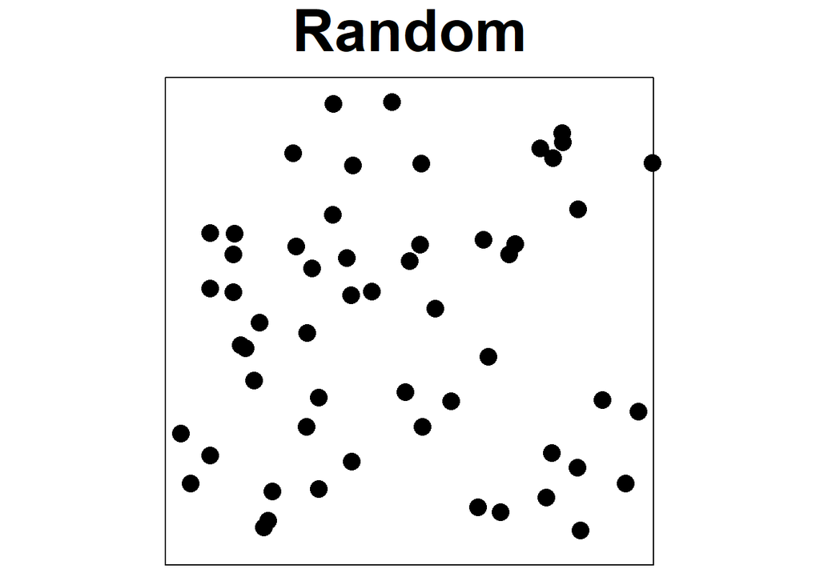

## Regular Pattern

A **regular spatial pattern** occurs when points are more evenly spaced than expected under randomness. It may arise when there is inhibition, competition, or planned spacing.

**Examples**

- Supermarkets, clinics, pharmacy stores placed to provide equal geographic coverage;
- trees competing for sunlight or nutrients;
- cells avoiding overlap;

**Pattern**

- points tend to be evenly spaced;
- very close pairs are uncommon;
- the pattern looks more ordered than random.

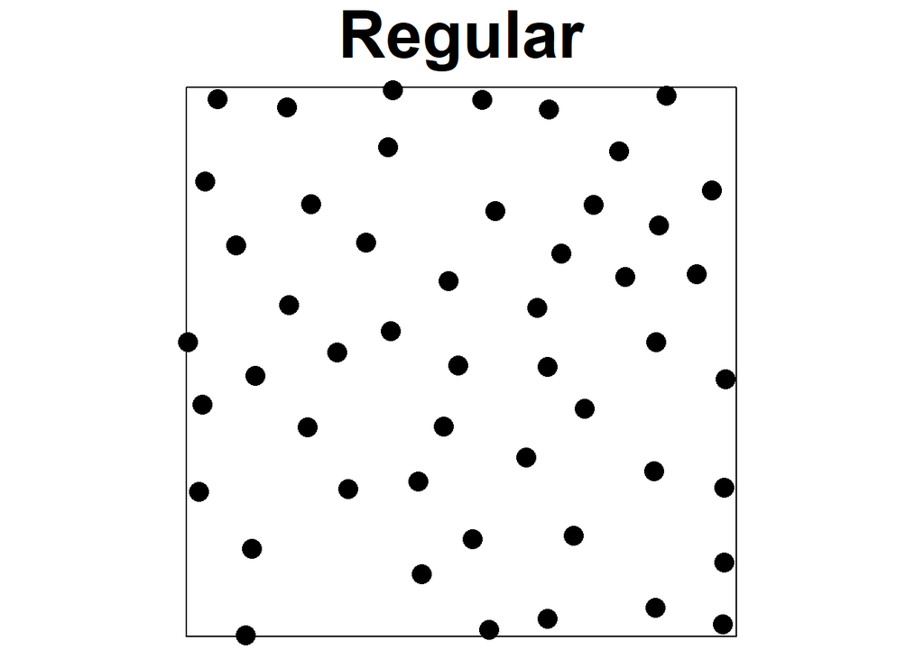

## Aggregated Pattern

An **aggregated**, or **clustered**, spatial pattern occurs when points tend to occur close together. It may arise when there are common risk factors, contagion, environmental exposure, or social/geographic clustering.

**Examples**

- disease cases clustered around an exposure source;
- infections spreading through local contact networks;
- cases concentrated near polluted areas.

**Pattern**

- points form visible clusters;
- some areas have high point density;
- other areas may have few or no points.

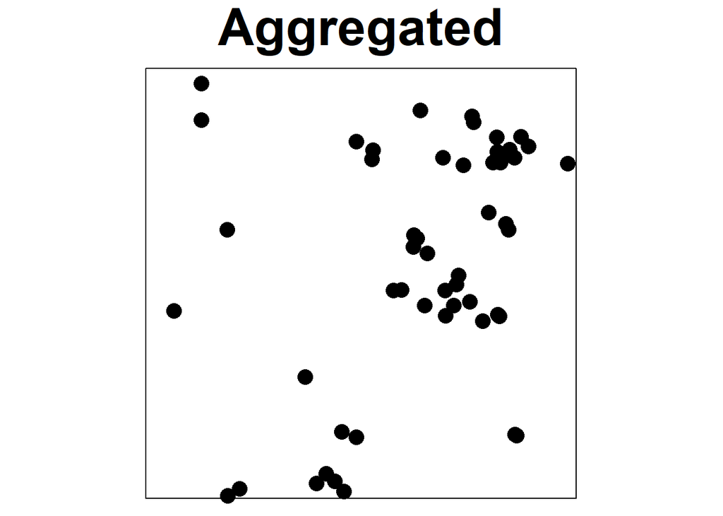

# R Packages

We will use `ggplot2` for plotting.

```r
library(ggplot2)
```

# Simulating Spatial Point Patterns

We will simulate three point patterns in the square region

$$W = [0, 1] \times [0, 1].$$

This simple window makes the examples easy to compare.

```r
set.seed(123)
```

The command `set.seed(123)` makes the simulation reproducible. Everyone running this code will obtain the same simulated patterns.

# Random Pattern Simulation

A random pattern can be simulated by generating independent uniform $x$- and $y$-coordinates.

```r
n_random <- 100

random_df <- data.frame(
  x = runif(n_random, 0, 1),
  y = runif(n_random, 0, 1),
  pattern = "Random"
)

head(random_df)
```

```
##           x         y pattern
## 1 0.2875775 0.5999890  Random
## 2 0.7883051 0.3328235  Random
## 3 0.4089769 0.4886130  Random
## 4 0.8830174 0.9544738  Random
## 5 0.9404673 0.4829024  Random
## 6 0.0455565 0.8903502  Random
```

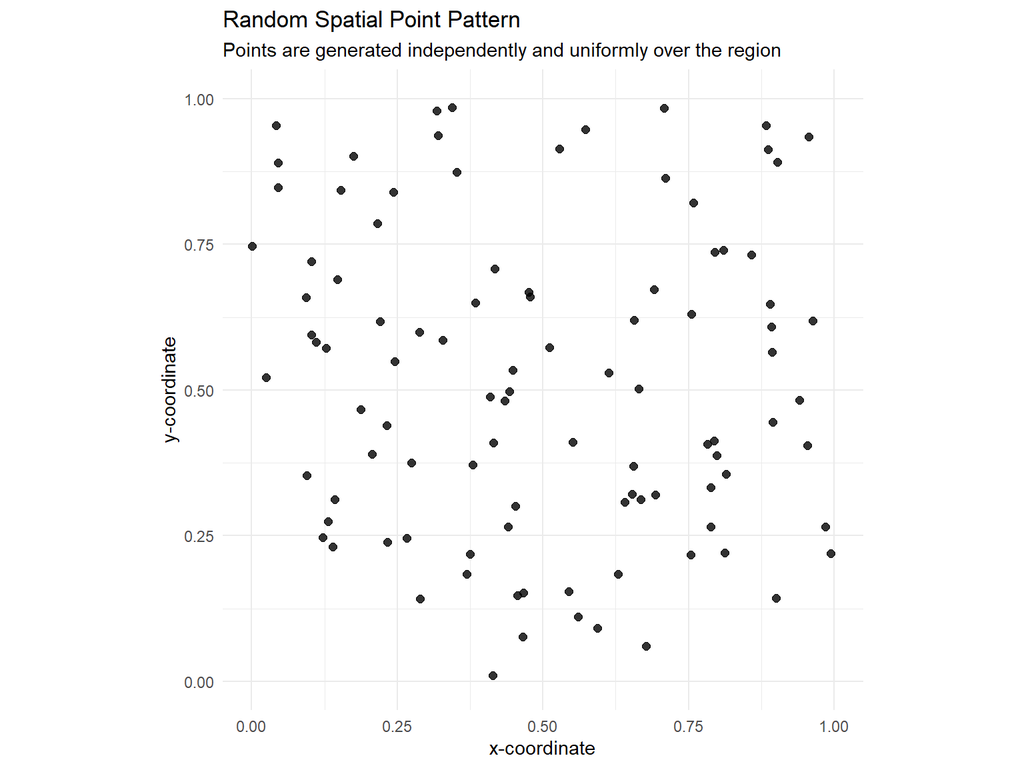

```r
ggplot(random_df, aes(x = x, y = y)) +
  geom_point(size = 2, alpha = 0.8) +
  coord_equal(xlim = c(0, 1), ylim = c(0, 1)) +
  labs(
    title = "Random Spatial Point Pattern",
    subtitle = "Points are generated independently and uniformly over the region",
    x = "x-coordinate",
    y = "y-coordinate"
  ) +
  theme_minimal()
```

# Regular Pattern Simulation

A regular pattern can be simulated using a grid of points. To make the pattern look slightly more realistic, we add a small amount of random jitter.

```r
grid_size <- 10

regular_df <- expand.grid(
  x = seq(0.05, 0.95, length.out = grid_size),
  y = seq(0.05, 0.95, length.out = grid_size)
)

regular_df$x <- regular_df$x + rnorm(nrow(regular_df), mean = 0, sd = 0.015)
regular_df$y <- regular_df$y + rnorm(nrow(regular_df), mean = 0, sd = 0.015)
regular_df$pattern <- "Regular"

head(regular_df)
```

```
##           x          y pattern
## 1 0.0393439 0.08298216 Regular
## 2 0.1538533 0.06968619 Regular
## 3 0.2462996 0.04602282 Regular
## 4 0.3447869 0.05814791 Regular
## 5 0.4357257 0.04378490 Regular
## 6 0.5493246 0.04285630 Regular
```

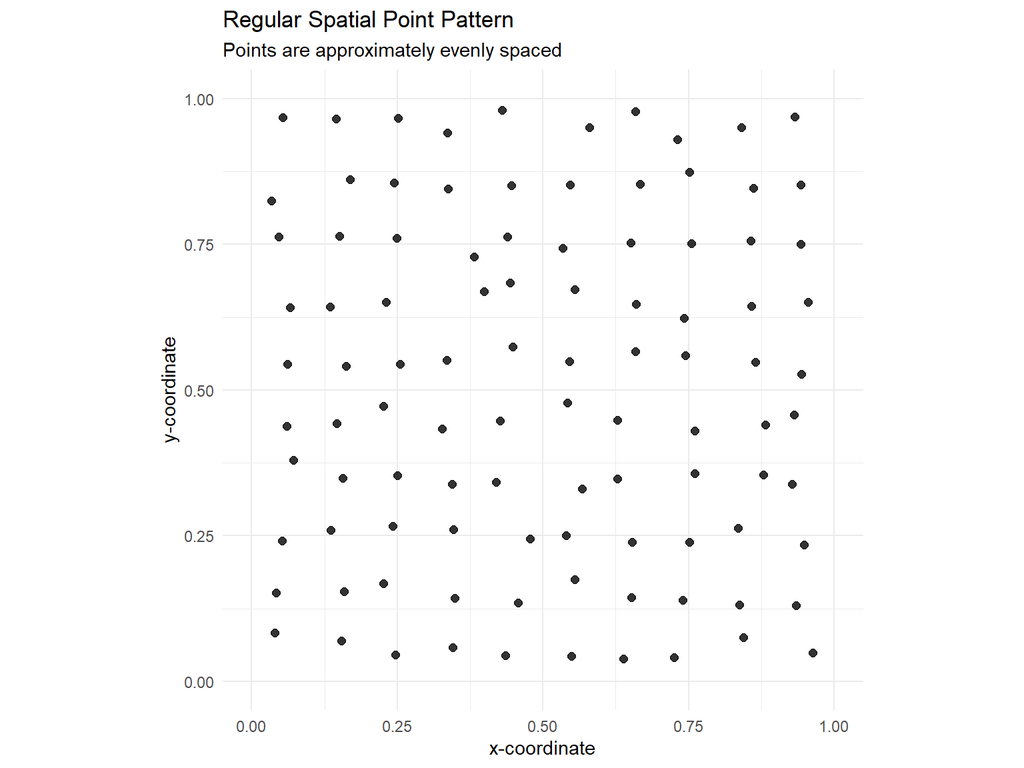

```r
ggplot(regular_df, aes(x = x, y = y)) +
  geom_point(size = 2, alpha = 0.8) +
  coord_equal(xlim = c(0, 1), ylim = c(0, 1)) +
  labs(
    title = "Regular Spatial Point Pattern",
    subtitle = "Points are approximately evenly spaced",
    x = "x-coordinate",
    y = "y-coordinate"
  ) +
  theme_minimal()
```

# Aggregated Pattern Simulation

An aggregated pattern can be simulated by first generating cluster centers and then generating points around each center.

```r
n_clusters <- 5
points_per_cluster <- 20

cluster_centers <- data.frame(
  cx = runif(n_clusters, 0.15, 0.85),
  cy = runif(n_clusters, 0.15, 0.85)
)

aggregated_df <- do.call(
  rbind,
  lapply(1:n_clusters, function(k) {
    data.frame(
      x = rnorm(points_per_cluster, cluster_centers$cx[k], sd = 0.05),
      y = rnorm(points_per_cluster, cluster_centers$cy[k], sd = 0.05),
      cluster = k
    )
  })
)

# Keep only points inside the study region
aggregated_df$x <- pmin(pmax(aggregated_df$x, 0), 1)
aggregated_df$y <- pmin(pmax(aggregated_df$y, 0), 1)
aggregated_df$pattern <- "Aggregated"

head(aggregated_df)
```

```
##           x         y cluster    pattern
## 1 0.3326197 0.7451880       1 Aggregated
## 2 0.2153503 0.7079596       1 Aggregated
## 3 0.3266598 0.7426487       1 Aggregated
## 4 0.3778945 0.7777766       1 Aggregated
## 5 0.4179395 0.7113652       1 Aggregated
## 6 0.3811196 0.7618786       1 Aggregated
```

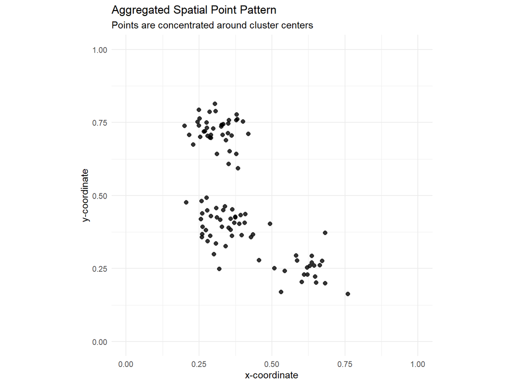

```r
ggplot(aggregated_df, aes(x = x, y = y)) +
  geom_point(size = 2, alpha = 0.8) +
  coord_equal(xlim = c(0, 1), ylim = c(0, 1)) +
  labs(
    title = "Aggregated Spatial Point Pattern",
    subtitle = "Points are concentrated around cluster centers",
    x = "x-coordinate",
    y = "y-coordinate"
  ) +
  theme_minimal()
```

# Comparing the Three Patterns

We can combine the simulated datasets and compare the three patterns side by side.

```r
combined_df <- rbind(
  random_df[, c("x", "y", "pattern")],
  regular_df[, c("x", "y", "pattern")],
  aggregated_df[, c("x", "y", "pattern")]
)
```

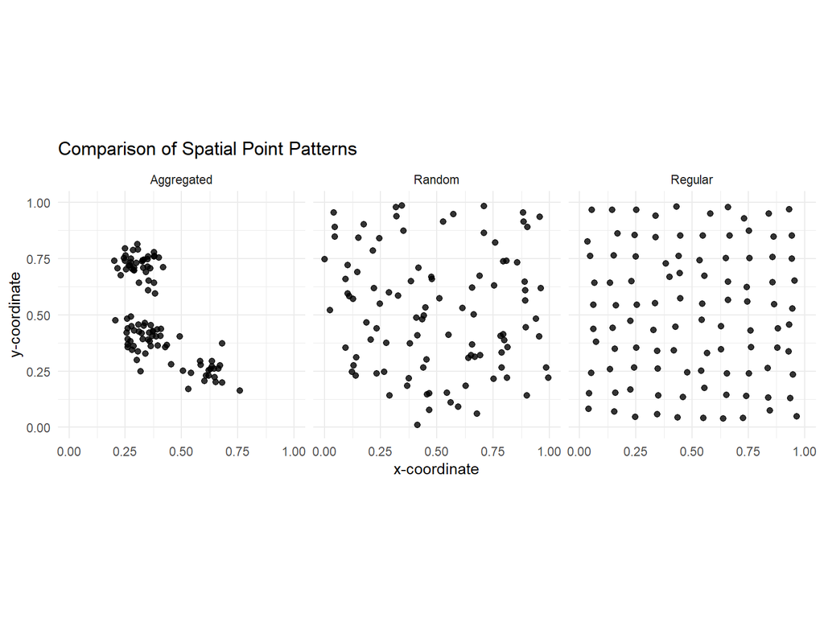

```r
ggplot(combined_df, aes(x = x, y = y)) +
  geom_point(size = 1.8, alpha = 0.8) +
  facet_wrap(~ pattern, nrow = 1) +
  coord_equal(xlim = c(0, 1), ylim = c(0, 1)) +
  labs(
    title = "Comparison of Spatial Point Patterns",
    x = "x-coordinate",
    y = "y-coordinate"
  ) +
  theme_minimal()
```

# Interpretation

The three simulated patterns have the same general study region but different spatial structures.

The **random pattern** shows no obvious organization. Points sometimes appear close together and sometimes far apart, but this occurs by chance.

The **regular pattern** shows more even spacing. There are few very close pairs of points. This pattern suggests inhibition, competition, or planned spacing.

The **aggregated pattern** shows visible clusters. Points are concentrated in certain areas, leaving other areas relatively empty. This pattern suggests clustering, contagion, or shared spatial risk factors.

# Biostatistical Motivation

In biostatistics and public health, spatial point patterns are useful for studying the geographic distribution of health-related events.

Examples include:

- locations of disease cases;
- residential locations of study participants;
- clinic or hospital locations;
- locations of environmental exposure measurements;
- locations of infection events.

For example, suppose each point represents the home location of a patient diagnosed with a disease. A random pattern may suggest no obvious spatial structure. A regular pattern may suggest systematic sampling or spatial separation. An aggregated pattern may suggest localized risk factors, disease transmission, or environmental exposure.

# Summary Table

| Pattern type | Description | Possible explanation |
| --- | --- | --- |
| Regular | Points are evenly spaced | Inhibition, competition, planned placement |
| Random | Points have no clear spatial structure | Complete spatial randomness |
| Aggregated | Points form clusters | Shared risk factors, contagion, environmental exposure |

# Discussion Questions

1. In a public health study, what might cause disease cases to appear clustered?
2. Why might clinic locations show a regular pattern?
3. Can a pattern look clustered even if it was generated randomly?
4. Why is visual inspection useful but not sufficient for formal spatial analysis?
5. What additional information would be needed to distinguish clustering due to population density from clustering due to disease risk?

# Optional Extension: Nearest Neighbor Distances

One simple way to compare point patterns is to examine nearest neighbor distances. Regular patterns tend to have larger nearest neighbor distances, while aggregated patterns tend to have smaller nearest neighbor distances.

```r
nearest_distance <- function(df) {
  coords <- as.matrix(df[, c("x", "y")])
  d <- as.matrix(dist(coords))
  diag(d) <- Inf
  apply(d, 1, min)
}

nn_df <- data.frame(
  distance = c(
    nearest_distance(random_df),
    nearest_distance(regular_df),
    nearest_distance(aggregated_df)
  ),
  pattern = rep(
    c("Random", "Regular", "Aggregated"),
    times = c(nrow(random_df), nrow(regular_df), nrow(aggregated_df))
  )
)
```

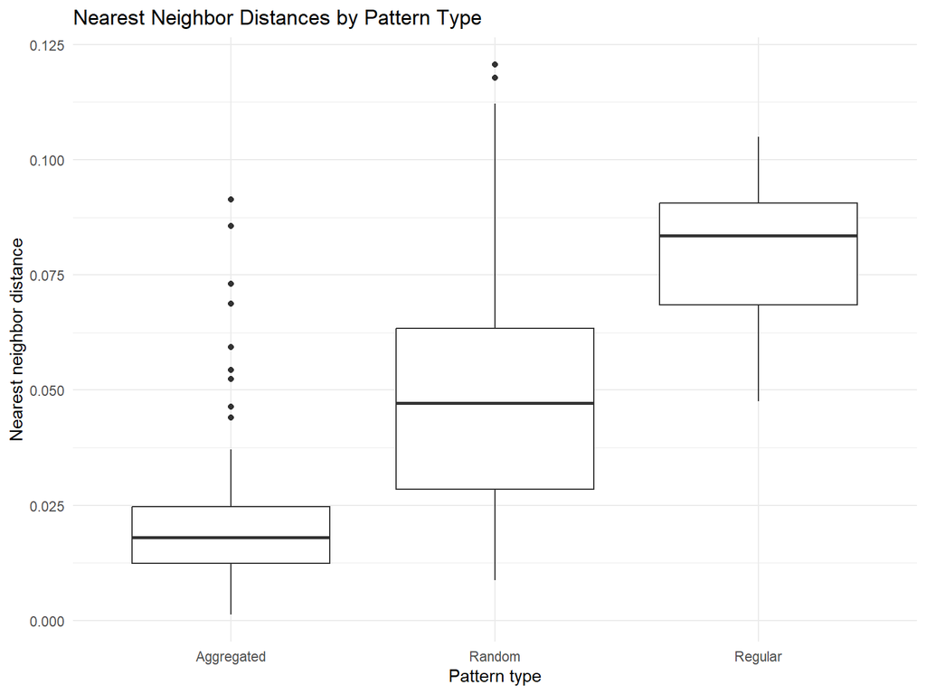

```r
ggplot(nn_df, aes(x = pattern, y = distance)) +
  geom_boxplot() +
  labs(
    title = "Nearest Neighbor Distances by Pattern Type",
    x = "Pattern type",
    y = "Nearest neighbor distance"
  ) +
  theme_minimal()
```

The regular pattern tends to have larger nearest neighbor distances because points are more evenly separated. The aggregated pattern tends to have smaller nearest neighbor distances because points occur close together within clusters.

# Concluding Remarks

Spatial point pattern analysis provides tools for studying the arrangement of events in space. Visual inspection is a useful starting point, but formal statistical methods are often needed to determine whether an observed pattern differs significantly from complete spatial randomness.

In practice, interpretation should consider the scientific context, the study design, the observation window, and possible spatial variation in the underlying population at risk.